# Computational Mathematics

## Project A: Convex Hull

## 2025-4-25

```python
import matplotlib.pyplot as plt
import math
import random
```

### Question A.1.

The convex hull of a set of discrete n points in 1D (a line) is exactly $[min point, max point]$.

Algorithm: Traverse the given point set to find minimum and maximum and return $[min, max]$.

Runtime complexity: Traverse the point set exactly once, so $O(n)$.

### Question A.2.

Consider apply convex hull algorithm to $\{(n_i, n_i^2),i=1,2,...,n\}$: Note that (i) Non-linearity avoids degenerating into the 1D case. (ii) The mapped shape is itself convex.

Algorithm:

1. Apply our convex hull algorithm on the points $(n_i, n_i^2)$, $i=1,2,...,N$.
2. The x-components of the convex hull is the set S sorted in cyclic order.

Convex hull algorithm can work as sorting algorithm, so its complexity shouldn't be smaller than the lowerbound of sorting. Hence the minimal runtime complexity of convex hull algorithm in 2D is at least $O(nlogn)$.

### Question A.3.

```python
def cross(x, y, c):
    #cross>0: left turn, cross<0: right turn, cross=0: colinear
    return (y[0]-x[0])*(c[1]-x[1]) - (y[1]-x[1])*(c[0]-x[0])
```

```python
def distance_squared(x, y):
    return (x[0]-y[0])**2 + (x[1]-y[1])**2
def polar_angle(x, y):
    return math.atan2(x[1]-y[1], x[0]-y[0])
```

```python
def Graham_scan(points):
    pts = points.copy()
    if len(pts) <= 2:
        return pts

    b = min(pts, key = lambda pt:(pt[1], pt[0]))

    pts.sort(key =lambda p:(polar_angle(p,b), distance_squared(p,b)))

    vertices = [pts[0], pts[1]]

    for c in pts[2:]:
        #len >= 2 is to take the case that b a_1 a_2 a_3... is colinear into consideration
        while len(vertices) >= 2 and cross(vertices[-2], vertices[-1], c) <= 0:
            vertices.pop()
        vertices.append(c)

    return vertices
```

```python
def plotting(pts, vertices):
    x,y = zip(*pts)
    vx, vy = zip(*(vertices + [vertices[0]]))
    plt.scatter(x, y, c='black', label='Given points')
    plt.plot(vx, vy, c='blue', label='Convex hull')
    plt.xlabel('x')
    plt.ylabel('y')
    plt.title('Convex Hull')
    plt.grid(True)
    plt.legend()
    plt.axis('equal')
    plt.tight_layout()
    plt.show()
```

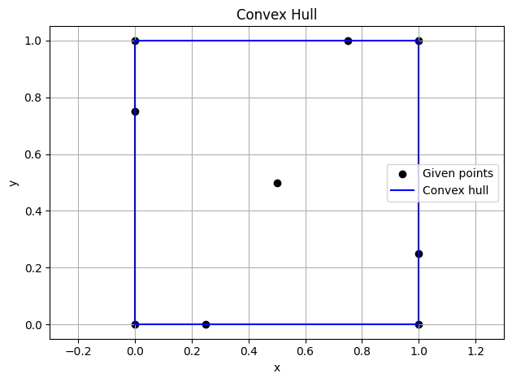

```python
pts = [(0, 0), (1, 0), (1, 1), (0, 1), (0.5, 0.5), (0.25, 0), (1, 0.25), (0.75, 1), (0, 0.75)]
plotting(pts, Graham_scan(pts))
```

### Question A.4.

```
Test 1:
Points: [(0.5411161199040299, 0.5880359023195371), (0.8592777316667989, 0.6293808790488115), (0.1177564341457078, 0.33070497668934873), (0.31818409066407605, 0.7636151484294296), (0.45944996676705174, 0.4566450270879848), (0.4738260913747243, 0.8055317976247042), (0.03589641369173113, 0.521841050148…
Convex Hull: [(0.2149985145216171, 0.006023753816890354), (0.5896614128815352, 0.006310092570770198), (0.8544015923742776, 0.07214517160995637), (0.99628172059049, 0.3676980201365637), (0.9825959529454693, 0.5911957546609058), (0.8373875703726523, 0.9887220942965221), (0.2651198416325138, 0.97825794…
```

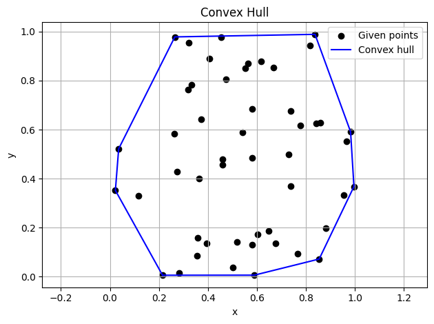

```
Test 2:
Points: [(0.1331829199167074, 0.01095490593769477), (0.2500709305960057, 0.3817671690969806), (0.6560363910682933, 0.34116547920439755), (0.6847847042326194, 0.9394158208941416), (0.9401381025186306, 0.9146213593874942), (0.6607111930497966, 0.3682722252021291), (0.5978046233239815, 0.94605709514222…
Convex Hull: [(0.1331829199167074, 0.01095490593769477), (0.7930642300915508, 0.035153601558591596), (0.9257626252717794, 0.3616698439530137), (0.9574699769015848, 0.6689896095456856), (0.9401381025186306, 0.9146213593874942), (0.8958266347198198, 0.9494683353913193), (0.48202335309971367, 0.9871568…
```

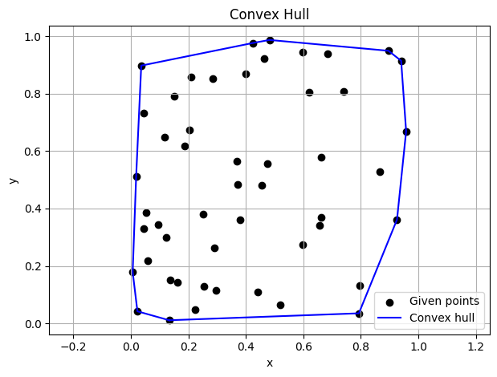

```
Test 3:
Points: [(0.13261490325327652, 0.2792848816869289), (0.29439774009040587, 0.5362050790513783), (0.8701089278490588, 0.04493912272533418), (0.9274360658114099, 0.938694374547116), (0.09771596916309622, 0.2924557408687487), (0.8391561296589409, 0.5458311958436506), (0.5980317255076623, 0.2032843533438…
Convex Hull: [(0.8701089278490588, 0.04493912272533418), (0.9995286704472394, 0.050131016687607), (0.997421182757909, 0.523193863692187), (0.9274360658114099, 0.938694374547116), (0.6821958630246222, 0.9879519980454612), (0.017924474172329785, 0.8227925962630918), (0.011154717104041922, 0.7773337023…
```

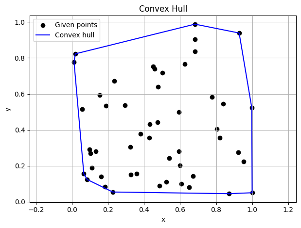

```
Test 4:
Points: [(0.20100197749595128, 0.17846300026278206), (0.7014440983635486, 0.40827035748324125), (0.9008222560043366, 0.11359152330605338), (0.34109698919492026, 0.3249529092857344), (0.7713971260187492, 0.24071727424060607), (0.564552407550489, 0.8879371501356147), (0.49379131090042494, 0.7154407034…
Convex Hull: [(0.24785078514275005, 0.09016736671665615), (0.9008222560043366, 0.11359152330605338), (0.9504370637241485, 0.2096092330299565), (0.9557806402280432, 0.9894956350461562), (0.954419470578345, 0.9927246627831635), (0.30603385877690525, 0.9923615954955799), (0.053863373462525344, 0.974396…
```

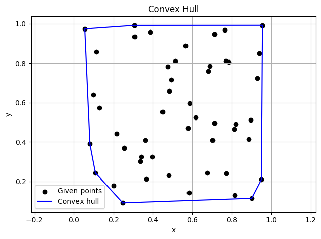

```
Test 5:
Points: [(0.40174964236406996, 0.16323656979508905), (0.7600833045584761, 0.26920416239640765), (0.4821990149950529, 0.24750259848865708), (0.1561618184349165, 0.07603873043516907), (0.6893012710781258, 0.3782746531868162), (0.32158330881643715, 0.9144291414628347), (0.04947047019580586, 0.895151487…
Convex Hull: [(0.17166015915929722, 0.013202242621143445), (0.32448033963605283, 0.029146662323624284), (0.9018293981309585, 0.17408689772705055), (0.9405504577758101, 0.1877266476324816), (0.9873728885766974, 0.4662162389840926), (0.849349951961419, 0.9782794347001839), (0.3935780933431656, 0.97686…
```

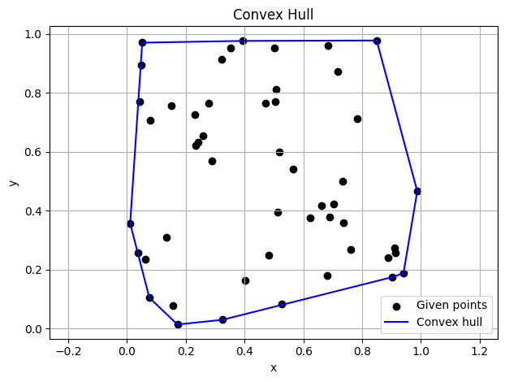

```
Test 6:
Points: [(0.7434319521026536, 0.26761884769245015), (0.009283372995660177, 0.9887739670368634), (0.15669970155980373, 0.25922014467828536), (0.5449806490388837, 0.5316187807227742), (0.614445691185758, 0.9490343525567906), (0.11573728567224828, 0.012295320203219107), (0.9133605400139998, 0.527333462…
Convex Hull: [(0.11573728567224828, 0.012295320203219107), (0.680527737208291, 0.03125316267113254), (0.9893465898058535, 0.042641413608575096), (0.9706048769306239, 0.5332585696618233), (0.9199317422654676, 0.66419968962065), (0.8681948400194509, 0.7588916283194952), (0.6907543654680233, 0.97680762…
```

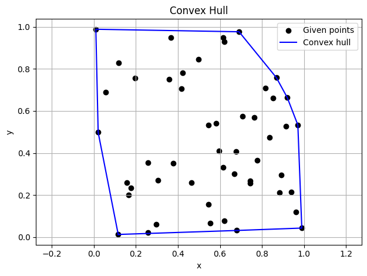

```
Test 7:
Points: [(0.7239490081158821, 0.4149516161958804), (0.7038952450270942, 0.7926542628450721), (0.7928502119827265, 0.31791738554682847), (0.6684915754686335, 0.9979430144857603), (0.33186607539229485, 0.5108579375186063), (0.22248804701688774, 0.5496148060483501), (0.5007476982711959, 0.9845531526768…
Convex Hull: [(0.7090747525937436, 0.09145979762476164), (0.9806562194082249, 0.2182664934979296), (0.9936174670629326, 0.7023357456480002), (0.9687335493293416, 0.9929891623312317), (0.6684915754686335, 0.9979430144857603), (0.19337207487838204, 0.9993584918942354), (0.018196266834144326, 0.9529669…
```

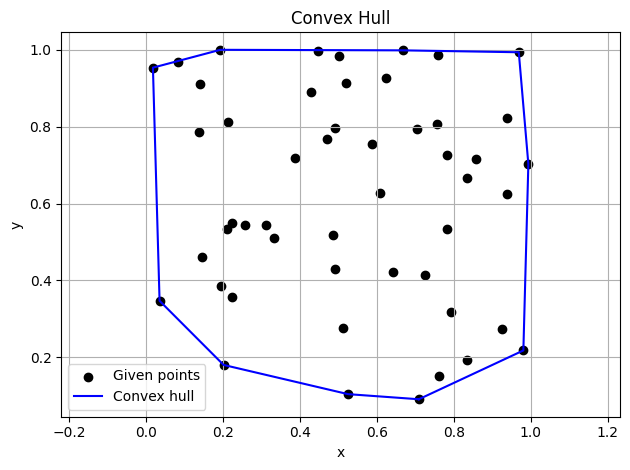

```
Test 8:
Points: [(0.718888644922273, 0.7455701876088399), (0.19729531893073338, 0.015620880960347527), (0.6905961240318212, 0.41502119683368954), (0.3764763694510205, 0.0017946048688195493), (0.8070028438317551, 0.663750722513381), (0.8668643581759288, 0.400763359666639), (0.16637784495000418, 0.91831683436…
Convex Hull: [(0.3764763694510205, 0.0017946048688195493), (0.7717192727916926, 0.07458215489366948), (0.8799598938452972, 0.10392696040924543), (0.9506299541549704, 0.4925139939206411), (0.9756255190671913, 0.6635117878784965), (0.9967865143242538, 0.9553417295858746), (0.7327601827116887, 0.987393…
```

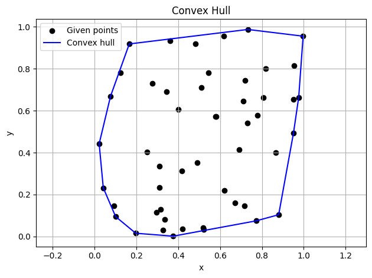

```
Test 9:
Points: [(0.6169826007556144, 0.41411475668443887), (0.41829173373310147, 0.34615541686632434), (0.28476160110132775, 0.04967426394965957), (0.5551870710040666, 0.3641215514081414), (0.09967386455225002, 0.17682587963470375), (0.05963929811467683, 0.25155908020868845), (0.0005033632482016603, 0.7920…
Convex Hull: [(0.12654152227166582, 0.009794234678945024), (0.4326931525299872, 0.035410458853290416), (0.7491158567651292, 0.11282155394355475), (0.9603460267558255, 0.2511002484458915), (0.9332044634562887, 0.5502798181891052), (0.9130069277411959, 0.7318514390374377), (0.7606179532555779, 0.96332…
```

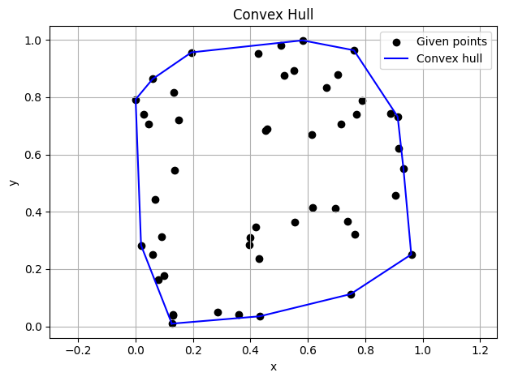

```
Test 10:
Points: [(0.8130990803332183, 0.03305779961718103), (0.7033010052612092, 0.017058479627264922), (0.2981954431771131, 0.9293701659042569), (0.6094201058106093, 0.6623213683454783), (0.9680992768770664, 0.551656415115193), (0.8896152015352209, 0.2771053944272015), (0.5982868854326003, 0.29383582149059…
Convex Hull: [(0.7033010052612092, 0.017058479627264922), (0.8130990803332183, 0.03305779961718103), (0.9982614587585402, 0.1284800098326574), (0.9680992768770664, 0.551656415115193), (0.9358769438346187, 0.9716865808506026), (0.14712744371901287, 0.9778417453039768), (0.05682457650614392, 0.5270909…
```

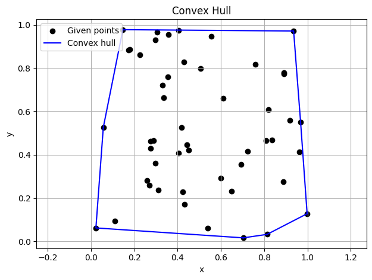

```python
for i in range(10):
    pts = [(random.uniform(0,1), random.uniform(0,1)) for _ in range(50)]
    print(f"Test {i+1}:")
    print("Points:", pts)
    print("Convex Hull:", Graham_scan(pts), "\n")
    plotting(pts, Graham_scan(pts))
```

### Question A.5.

Complexity Analysis

1. Finding the pivot has complexity $O(n)$, as it traverses the point set only once (although with multiple parameters, but this just contributes to a constant to complexity).
2. Sorting points has the same complexity as the sort function, which is complexity $O(nlogn)$.
3. Let's examine what does the scan do to a fixed point in forward-traversal and backtracking. Firstly it will be visited once in the forward traversal. The next backtracking might pop it out or incorporate it into the hull. Once incorporated it won't be back-visited anymore. Hence a given point will be visited once in the forward traversal and only once in all the backtrackings. The complexity is $O(n)$.

The total complexity is $O(nlogn)$.

### Question A.6.

```python
def lower_tangent(A, B):
    ia = A.index(max(A, key=lambda p: (p[0], -p[1])))
    ib = B.index(min(B, key=lambda p: (p[0], p[1])))

    while True:
        update = False

        original_ib = ib
        while (ib + 1) % len(B) != original_ib:
            c = cross(A[ia], B[ib], B[(ib + 1) % len(B)])
            if c < 0 or (c == 0 and distance_squared(A[ia], B[(ib + 1) % len(B)]) > distance_squared(A[ia], B[ib])):
                ib = (ib + 1) % len(B)
                update = True
            else: break

        original_ia = ia
        while (ia - 1) % len(A) != original_ia:
            c = cross(B[ib], A[ia], A[(ia - 1) % len(A)])
            if c > 0 or (c == 0 and distance_squared(B[ib], A[(ia - 1) % len(A)]) > distance_squared(B[ib], A[ia])):
                ia = (ia - 1) % len(A)
                update = True
            else: break

        if not update:
            break

    return (ia, ib)
```

```python
def upper_tangent(A, B):
    A_ = [(p[0], -p[1]) for p in A][::-1]
    B_ = [(p[0], -p[1]) for p in B][::-1]
    ia_, ib_ = lower_tangent(A_, B_)

    return (len(A) - 1 - ia_, len(B) - 1 - ib_)
```

```python
def merge(A, B):
    if A == []: return B
    if B == []: return A

    ia_u, ib_u = upper_tangent(A, B)
    ia_l, ib_l = lower_tangent(A, B)

    hull = []

    i = ia_u
    while hull.append(A[i]) or i != ia_l:
        i = (i + 1) % len(A)

    i = ib_l
    while hull.append(B[i]) or i != ib_u:
        i = (i + 1) % len(B)

    return hull
```

```python
def divide_and_conquer(points):
    if len(points) <= 5:
        return Graham_scan(points)
    pts = sorted(points, key=lambda p: (p[0],p[1]))

    midval = len(pts)//2
    A = divide_and_conquer(pts[:midval])
    B = divide_and_conquer(pts[midval:])

    return merge(A, B)
```

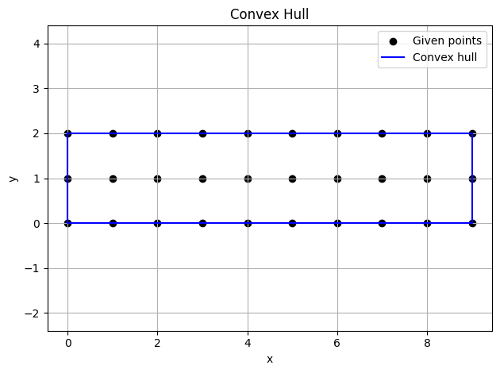

```python
#Test this algorithm
pts = [(i, 0) for i in range(10)] + [(i, 1) for i in range(10)] + [(i, 2) for i in range(10)]
plotting(pts, divide_and_conquer(pts))
```

### Question A.7.

```
Test 1:
Points: [(0.018159885524079433, 0.368836706849323), (0.7817225366667356, 0.6954635466942318), (0.9238338246316843, 0.2171943362735843), (0.09913075020618967, 0.6933845856519043), (0.2564210703845624, 0.6256190046607767), (0.17702943779276492, 0.6695977345207841), (0.8084987620743447, 0.8808421231926…
Convex Hull: [(0.16584019101451097, 0.016995994981207185), (0.9303975744326397, 0.07534960217141073), (0.9961933183466263, 0.8077785248124351), (0.9617499330363166, 0.91154451935996), (0.9284914280164993, 0.9471278625814056), (0.8481096983421675, 0.9637479923388378), (0.1341718463009507, 0.965581798…
```

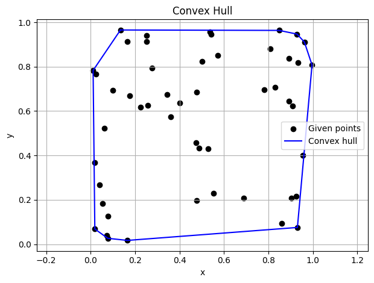

```
Test 2:
Points: [(0.06999861658750806, 0.5008509992054014), (0.6340585809580339, 0.3551626332898161), (0.6050787370914972, 0.10013051141779217), (0.988779002237956, 0.2945767686200812), (0.5397609401414066, 0.3651166542973645), (0.9091760522414655, 0.8168959580257141), (0.708091664284344, 0.2206313552566953…
Convex Hull: [(0.10601342557100513, 0.06166832804901157), (0.9633020916179647, 0.07254568270712536), (0.988779002237956, 0.2945767686200812), (0.9091760522414655, 0.8168959580257141), (0.6052922247280522, 0.9395271704633201), (0.5061019109189634, 0.9664074942207651), (0.14301243895798665, 0.96494216…
```

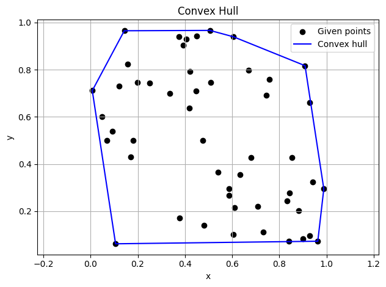

```
Test 3:
Points: [(0.11255314676996253, 0.6943745563956424), (0.7250826111073032, 0.24487437984308058), (0.8455723016882347, 0.5787660583133013), (0.7757111532320975, 0.8424765069594851), (0.245673334390764, 0.23498098789588073), (0.39940084611466664, 0.019387267702455024), (0.8390020490669785, 0.86952140724…
Convex Hull: [(0.39940084611466664, 0.019387267702455024), (0.9636197630268248, 0.13333414907512797), (0.9848145418705879, 0.722912171981429), (0.8390020490669785, 0.8695214072413133), (0.50419145890689, 0.9685800204170949), (0.26837655915761915, 0.9928290582270722), (0.052047438969159865, 0.8317083…
```

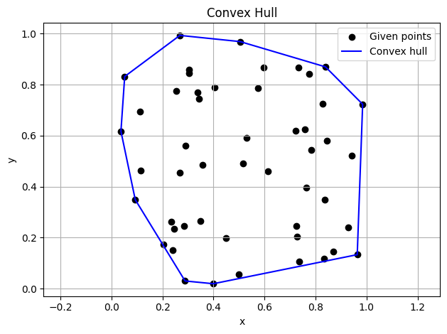

```
Test 4:
Points: [(0.5174128013642817, 0.06781498056047974), (0.4512021378714922, 0.7063477376045191), (0.1240573796617761, 0.2241050744013685), (0.5898286224895771, 0.8014901137427508), (0.5594975937362666, 0.022438900184675536), (0.06472624631197532, 0.31937357291096646), (0.27602717187701664, 0.4401510213…
Convex Hull: [(0.5594975937362666, 0.022438900184675536), (0.9351752114448935, 0.1700243140605051), (0.988473481195134, 0.28123116190980346), (0.9836369035871821, 0.7355644250989126), (0.9661053225348862, 0.892132840500936), (0.6468054968859248, 0.9809470261012853), (0.10722827181501138, 0.879710156…
```

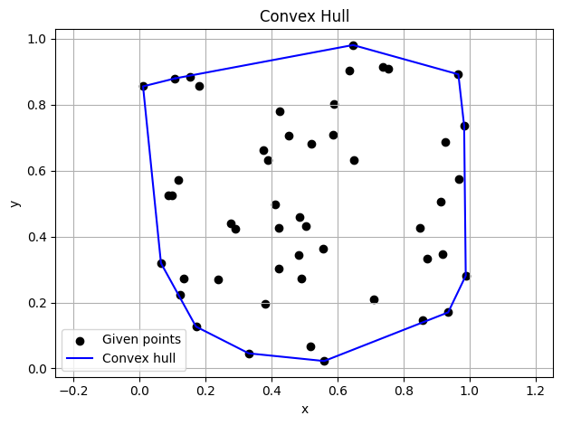

```
Test 5:
Points: [(0.026781372326547315, 0.5157977894660292), (0.4951356414972746, 0.5000790697102989), (0.07854088465787035, 0.9089414060191341), (0.5964536773224105, 0.501344731027636), (0.4983753191803304, 0.3904050161696827), (0.7015884971244131, 0.27740518407214887), (0.8741620030059917, 0.5227678802663…
Convex Hull: [(0.26625778294286195, 0.02975101413321113), (0.8658570085344357, 0.0621047642837288), (0.9857378277637298, 0.8537085878080132), (0.44589466602820405, 0.9744717770535489), (0.3243433670992393, 0.9823766927876634), (0.023815962794400014, 0.9216303475740149), (0.014101757363618406, 0.8727…
```

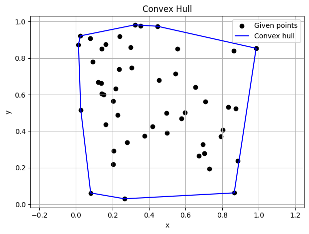

```
Test 6:
Points: [(0.6065234872944375, 0.07691229220687101), (0.4456912762934443, 0.4835001482442962), (0.5210473385270092, 0.17183714280089024), (0.7774653077061734, 0.7398662644703804), (0.8864275860014358, 0.6753888515965366), (0.011824501948960009, 0.8778213712092268), (0.348400208382152, 0.1611537957628…
Convex Hull: [(0.32356547752226583, 0.015660453612213243), (0.6889249665986926, 0.03806483886169143), (0.958968744362276, 0.07667437983868242), (0.9567192899474279, 0.270260937000407), (0.9233288077915888, 0.8080970744373609), (0.21881474433316217, 0.9779936739030861), (0.0744138853830123, 0.9772754…
```

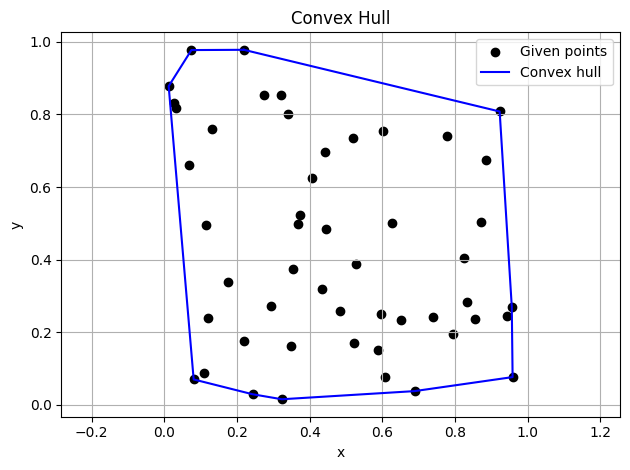

```
Test 7:
Points: [(0.03180358087339574, 0.06354174065582019), (0.6260830553519785, 0.15547842201540119), (0.7919171114730906, 0.6193464516187328), (0.5860347664275029, 0.2502275811405512), (0.230345167435696, 0.7824076145649026), (0.5267135275255562, 0.23647272455819257), (0.5810768871180786, 0.2424166450142…
Convex Hull: [(0.2000996502211393, 0.0170573289276732), (0.8867431081986088, 0.06410357615702855), (0.9579344937295134, 0.24627432597244792), (0.9850282155750447, 0.8334707210669581), (0.6489869973369704, 0.9829878582883285), (0.32955682449525125, 0.952573599852603), (0.1961380021197754, 0.938910749…
```

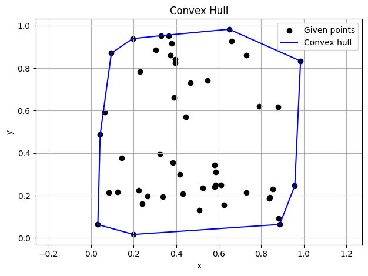

```
Test 8:
Points: [(0.9092615521300856, 0.8745777160401692), (0.34519955079993425, 0.07200233950669721), (0.145814840098903, 0.5930589785237599), (0.22008090970646654, 0.9532546251685396), (0.39848083830349945, 0.027412691939891598), (0.9074850807465593, 0.7639259979753105), (0.5130544090687759, 0.77414058028…
Convex Hull: [(0.39848083830349945, 0.027412691939891598), (0.6145261956121115, 0.08526063189269839), (0.9941866747608261, 0.20502592330551528), (0.9974005514331614, 0.46103468278636883), (0.9889706767927328, 0.9522420867242885), (0.7627275677726989, 0.9844487460828328), (0.7008678672764117, 0.98347…
```

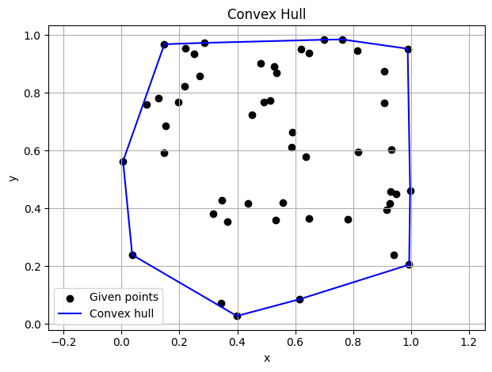

```
Test 9:
Points: [(0.3666799050105336, 0.8756938009988915), (0.23660126866900488, 0.888048222274238), (0.15202595089106974, 0.5550513391335169), (0.40954207924687214, 0.7959964269130165), (0.22442364010773663, 0.5800942348960997), (0.5082230502223901, 0.9025835041592046), (0.8061073889640137, 0.0928847158992…
Convex Hull: [(0.4635020325168331, 0.00860463620976748), (0.8061073889640137, 0.09288471589924119), (0.922952487947449, 0.7332621647045107), (0.9126902203135351, 0.8600028529973277), (0.8750300816377075, 0.9657255267289928), (0.7131357767801095, 0.9861484812170719), (0.2685969911519974, 0.9886021118…
```

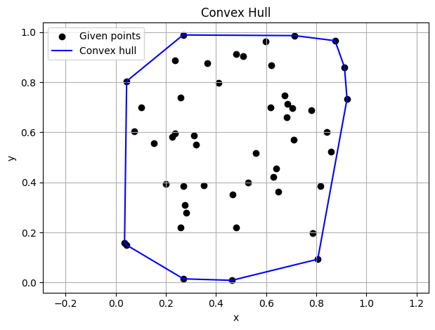

```
Test 10:
Points: [(0.13529793905692544, 0.9404417301139308), (0.44124146207991355, 0.4340212283376286), (0.8418590228789007, 0.3506652255752253), (0.6039346975855039, 0.9084707077139602), (0.6770119164919459, 0.2978834224929211), (0.34063123801128037, 0.6558591112507727), (0.25800332900832224, 0.412407300492…
Convex Hull: [(0.8206765648598744, 0.02846038976751719), (0.9336442781712185, 0.06805344482220632), (0.9937506498431044, 0.34652063243265996), (0.9397537238677925, 0.8593408602121753), (0.5397470279682807, 0.975923160882185), (0.13529793905692544, 0.9404417301139308), (0.008469718922190395, 0.849757…
```

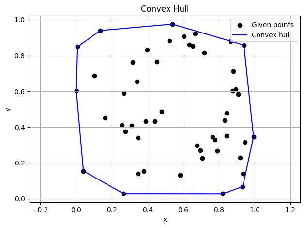

```python
for i in range(10):
    pts = [(random.uniform(0,1), random.uniform(0,1)) for _ in range(50)]
    print(f"Test {i+1}:")
    print("Points:", pts)
    print("Convex Hull:", Graham_scan(pts), "\n")
    plotting(pts, divide_and_conquer(pts))
```

### Question A.8.

For a convex hull in 3D, each of its face is a polygon and must has at least three edges. Each edge is shared by exactly two faces, so we have $2E \geq 3F$. $F=2+E-V$ so $2E \geq 6+3E-3V$, thus $$ E \leq 3V-6 < 3V $$. $$F=2+E-V \leq 2V-4<2V$$.